# Hypothesis Testing: Comparing Means

Author

Global Health and Infectious Diseases Group - KCCR-KNUST, Ghana for ISARIC

## Hypothesis Testing: Comparing Means

In clinical research, we frequently ask questions like: “Do males and females have different platelet counts?” or “Does treatment A work better than treatment B?” Hypothesis testing provides a statistical framework to answer these questions with quantified uncertainty.

### The Hypothesis Testing Framework

A **hypothesis test** evaluates evidence against a null hypothesis ($H_0$) using sample data:

- **Null Hypothesis ($H_0$)**: There is **no difference** between groups (e.g., mean platelets in males = mean platelets in females)
- **Alternative Hypothesis ($H_1$)**: There **is a difference** between groups
- **Test Statistic**: A calculated value that measures how different the groups are
- **P-value**: The probability of observing data this extreme (or more) if $H_0$ is true
- **Significance Level ($\alpha$)**: Typically 0.05, the threshold for deciding when to reject $H_0$

**Warning**

**Important**: A p-value is **NOT** the probability that the null hypothesis is true. It’s the probability of observing data this extreme if the null hypothesis were true. This is a crucial distinction often misunderstood in research.

## Setting Up the Environment

We’ll analyze whether platelet counts differ between males and females using a two-sample t-test. The t-test is appropriate when comparing the means of two continuous variables across two independent groups.

```r
# Load the synthetic dataset
df <- read.csv(
  "https://raw.githubusercontent.com/EstebanGarciaG/Lectures/main/data/data_synth.csv"
)

# Convert platelets to numeric and suppress conversion warnings
df$labs_platelets_103ul <- suppressWarnings(as.numeric(df$labs_platelets_103ul))

df <- df[!is.na(df$labs_platelets_103ul) & df$demog_sex != "", ]

paste("Dataset prepared:")
```

```
[1] "Dataset prepared:"
```

```r
paste("Total observations:", nrow(df))
```

```
[1] "Total observations: 1000"
```

```r
paste("Variables: Platelets (10³/µL), Sex")
```

```
[1] "Variables: Platelets (10³/µL), Sex"
```

**Data Preparation**: We convert platelets to numeric (suppressing warnings) and remove rows with missing values in either platelet count or sex. This ensures clean, complete data for the t-test.

## Exploratory Analysis: Boxplot by Sex

Before conducting a formal hypothesis test, it’s important to visualize the data. A boxplot shows the distribution of platelet counts separately for males and females, making any differences immediately apparent.

### Creating the Boxplot

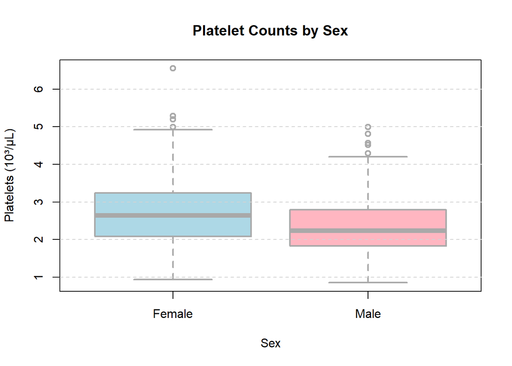

Figure 1: Distribution of platelet counts by sex

```r
boxplot(
  labs_platelets_103ul ~ demog_sex,
  data = df,
  main = "Platelet Counts by Sex",
  xlab = "Sex",
  ylab = "Platelets (10³/µL)",
  col = c("lightblue", "lightpink"),
  border = "darkgray",
  lwd = 2
)

grid(nx = NA, ny = NULL, col = "lightgray", lty = 2)
```

**What to Look For**: - Are the medians (center line) in each box substantially different? - Is there overlap in the interquartile ranges (the boxes)? - Are there outliers (points beyond the whiskers)?

Visual inspection helps determine if a statistical test is likely to find a significant difference.

## Separating Groups for Analysis

```r
group_male <- df$labs_platelets_103ul[df$demog_sex == "Male"]
group_female <- df$labs_platelets_103ul[df$demog_sex == "Female"]

paste("--- Descriptive Statistics ---")
```

```
[1] "--- Descriptive Statistics ---"
```

```r
paste(sprintf("Males (n = %d):", length(group_male)))
```

```
[1] "Males (n = 470):"
```

```r
paste(sprintf(
  "  Mean = %.2f, SD = %.2f, Median = %.2f",
  mean(group_male),
  sd(group_male),
  median(group_male)
))
```

```
[1] "  Mean = 2.33, SD = 0.72, Median = 2.23"
```

```r
paste(sprintf("Females (n = %d):", length(group_female)))
```

```
[1] "Females (n = 530):"
```

```r
paste(sprintf(
  "  Mean = %.2f, SD = %.2f, Median = %.2f",
  mean(group_female),
  sd(group_female),
  median(group_female)
))
```

```
[1] "  Mean = 2.69, SD = 0.85, Median = 2.64"
```

```r
paste(sprintf(
  "Difference in means: %.2f (10³/µL)",
  mean(group_male) - mean(group_female)
))
```

```
[1] "Difference in means: -0.36 (10³/µL)"
```

## The Two-Sample t-Test

### Concept

The **two-sample t-test** (also called independent samples t-test) compares the means of two independent groups. The test statistic is:

$$t = \frac{\overline{x}_1 - \overline{x}_2}{SE_{difference}}$$

where $SE_{difference} = \sqrt{\frac{s_1^2}{n_1} + \frac{s_2^2}{n_2}}$

The t-test assumes: 1. **Independence**: Observations within each group are independent 2. **Normality**: Data in each group is approximately normally distributed (t-test is robust to mild violations) 3. **Equal variances**: Variances are similar between groups (Welch’s t-test relaxes this assumption)

By default, R performs Welch’s t-test, which does not assume equal variances. This is generally recommended for real-world data.

### Performing the t-Test

```r
t_test_result <- t.test(group_male, group_female)

t_test_result
```

```
    Welch Two Sample t-test

data:  group_male and group_female
t = -7.2559, df = 996.57, p-value = 8.011e-13
alternative hypothesis: true difference in means is not equal to 0
95 percent confidence interval:
 -0.4578107 -0.2628974
sample estimates:
mean of x mean of y
 2.332789  2.693143
```

**Welch’s t-test**: R automatically performs Welch’s t-test by default, which does not assume equal variances between groups. This is more robust and generally recommended for real-world data. Use `var.equal = TRUE` only if you have strong evidence of equal variances.

## Interpreting the Results

**WarningKey Output Explained**

The t-test output includes:

| Component | Interpretation |
| --- | --- |
| **t statistic** | How many standard errors the difference in means is. Larger absolute values suggest greater differences. |
| **Degrees of freedom (df)** | Related to sample size; affects the critical value for the t-statistic. |
| **p-value** | Probability of observing a difference this large if the null hypothesis were true. |
| **95% CI** | Range of plausible values for the true difference in population means. |

```r
# Extract and display key results
t_stat <- t_test_result$statistic
p_val <- t_test_result$p.value
ci_lower <- t_test_result$conf.int[1]
ci_upper <- t_test_result$conf.int[2]

paste("--- Hypothesis Test Results Summary ---")
```

```
[1] "--- Hypothesis Test Results Summary ---"
```

```r
paste(sprintf("t-statistic: %.4f", t_stat))
```

```
[1] "t-statistic: -7.2559"
```

```r
paste(sprintf("p-value: %.4f", p_val))
```

```
[1] "p-value: 0.0000"
```

```r
paste(sprintf("95%% Confidence Interval: [%.2f, %.2f]", ci_lower, ci_upper))
```

```
[1] "95% Confidence Interval: [-0.46, -0.26]"
```

```r
# Decision
alpha <- 0.05
if (p_val < alpha) {
  decision <- "REJECT the null hypothesis"
  interpretation <- "There IS statistically significant evidence that platelet counts differ between males and females."
} else {
  decision <- "FAIL TO REJECT the null hypothesis"
  interpretation <- "There is NOT sufficient evidence that platelet counts differ between males and females."
}

paste(sprintf("Decision (α = 0.05): %s", decision))
```

```
[1] "Decision (α = 0.05): REJECT the null hypothesis"
```

```r
paste(sprintf("Interpretation: %s", interpretation))
```

```
[1] "Interpretation: There IS statistically significant evidence that platelet counts differ between males and females."
```

## Effect Size

Beyond p-values, it’s important to report **effect size**—a measure of the magnitude of the difference:

```r
# Calculate Cohen's d (standardized effect size)
pooled_sd <- sqrt(
  ((length(group_male) - 1) *
    sd(group_male)^2 +
    (length(group_female) - 1) * sd(group_female)^2) /
    (length(group_male) + length(group_female) - 2)
)

cohens_d <- (mean(group_male) - mean(group_female)) / pooled_sd

paste("--- Effect Size ---")
```

```
[1] "--- Effect Size ---"
```

```r
paste(sprintf("Cohen's d: %.3f", cohens_d))
```

```
[1] "Cohen's d: -0.455"
```

```r
# Interpret Cohen's d
if (abs(cohens_d) < 0.2) {
  interpretation <- "Negligible effect"
} else if (abs(cohens_d) < 0.5) {
  interpretation <- "Small effect"
} else if (abs(cohens_d) < 0.8) {
  interpretation <- "Medium effect"
} else {
  interpretation <- "Large effect"
}

paste(sprintf("Interpretation: %s", interpretation))
```

```
[1] "Interpretation: Small effect"
```

**Why Report Effect Size?**: Even with large samples, a statistically significant p-value might reflect a tiny, clinically unimportant difference. Effect size tells us whether the difference is practically meaningful.

## Key Takeaways

**Warning**

1. **Always visualize first**: Use boxplots or other graphics to understand the data before testing.
2. **p-value ≠ probability null is true**: A p-value of 0.05 does NOT mean there’s a 5% chance the null hypothesis is true.
3. **Report both p-values and effect sizes**: Statistical significance and practical significance are different.
4. **Check assumptions**: Verify that data approximate normality and groups are independent.
5. **Confidence interval is informative**: The CI shows the range of plausible differences and is often more useful than just a p-value.
6. **Multiple testing increases error**: If you conduct many tests, some will appear significant by chance. Consider multiple testing corrections if appropriate.

## Simple tables with `gtsummary` package

In addition to visualizations, tables are a great way to summarize your data. The `gtsummary` package in R allows you to create publication-ready summary tables. The syntax is straightforward and flexible, making it easy to customize tables for your specific needs.

```r
library(gtsummary)
df |>
  select(demog_sex, labs_platelets_103ul) |>
  tbl_summary(
    by = demog_sex,
    missing = "no",
    statistic = list(all_continuous() ~ "{mean} ({sd})")
  ) |>
  add_difference() |>
  add_overall()
```

| **Characteristic** | **Overall** N = 1,000<sup>1</sup> | **Female** N = 530<sup>1</sup> | **Male** N = 470<sup>1</sup> | **Difference**<sup>2</sup> | **95% CI**<sup>2</sup> | **p-value**<sup>2</sup> |
| --- | --- | --- | --- | --- | --- | --- |
| labs_platelets_103ul | 2.52 (0.81) | 2.69 (0.85) | 2.33 (0.72) | 0.36 | 0.26, 0.46 | <0.001 |

<sup>1</sup> Mean (SD)  
<sup>2</sup> Welch Two Sample t-test  
Abbreviation: CI = Confidence Interval

### When to Use the t-Test

- Comparing means between **two independent groups**
- Continuous outcome variable (e.g., platelet count)
- Approximately normal distributions
- **Not** for paired data (use paired t-test instead)
- **Not** for more than two groups (use ANOVA instead)

## R package to help with interpretation

As a beginner, you may find it helpful to use the `report` package in R, which provides plain-language interpretations of statistical results. This can help you understand the output of your tests and communicate findings effectively.

```r
if (!requireNamespace("report", quietly = TRUE)) {
  install.packages("report")
}
report::report(t_test_result)
```

```
Effect sizes were labelled following Cohen's (1988) recommendations.

The Welch Two Sample t-test testing the difference between group_male and
group_female (mean of x = 2.33, mean of y = 2.69) suggests that the effect is
negative, statistically significant, and small (difference = -0.36, 95% CI
[-0.46, -0.26], t(996.57) = -7.26, p < .001; Cohen's d = -0.46, 95% CI [-0.58,
-0.33])
```

**Warning**

**Tip**: Sometimes, you only need a single function from a package. In that case, you can use the `::` operator to call the function without loading the entire package. For example, `report::report()` calls the `report()` function from the `report` package, without attaching the entire package. In other cases, some pack may have conflicting function names, so using `::` ensures you are calling the correct function from the intended package. E.g. the `dplyr` and `MASS` packages both have a `select()` function, so you can use `dplyr::select()` to specify which one you want to use. A common convention is to load the library that you will use most often, and use `::` for functions from other packages or load the most infrequently used package last to avoid conflicts. In most cases therefore `library(MASS)` is loaded first before `library(dplyr)` so that `select()` will refer to the `dplyr` version of the function. Then if you need to use the `select()` function from the `MASS` package, you can call it as `MASS::select()`.